# UPA_projekt-03

# Grupiranje klastera k-sredina

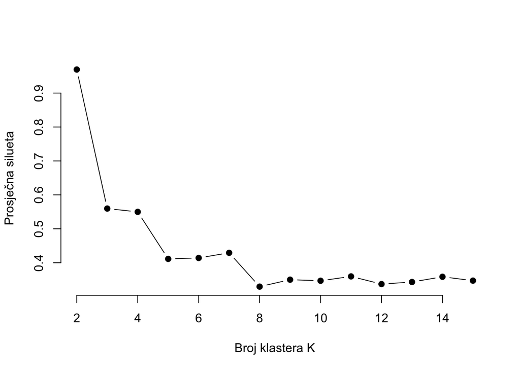

```r
#Metoda siluete
# prosječna silueta
avg_sil <- function(k) {
  km.res <- kmeans(kupci_bez_ID.s, centers = k, nstart = 25, iter.max = 50) # Povećan iter.max
  ss <- silhouette(km.res$cluster, dist(kupci_bez_ID.s))
  mean(ss[, 3])
}

#  wss za k = 2 do k = 15
k.values <- 2:15

#  avg silueta za 2-15 klastere
avg_sil_values <- map_dbl(k.values, avg_sil)

plot(k.values, avg_sil_values,
       type = "b", pch = 19, frame = FALSE,
       xlab = "Broj klastera K",
       ylab = "Prosječna silueta")
```

Prilikom odabira optimalnog broja klastera metodom siluete, tražimo broj klastera koji maksimizira prosječnu vrijednost siluete. Prosječna silueta mjeri kako je sličan objekt klasteru kojem je dodijeljen u usporedbi s drugim klasterima i varira u rasponu od -1 do +1. Veće vrijednosti ukazuju na bolje podudaranje objekata unutar klastera.

Na našem grafu, najveća vrijednost siluete je za k=2, što ukazuje na to da dva klastera pružaju najkonzistentniju unutarklastersku sličnost u odnosu na različitost među klasterima. Nakon k=2, vrijednosti siluete opadaju, što sugerira da dodavanje više klastera smanjuje unutarklastersku sličnost.

Stoga, na temelju ovog grafikona, izabrali bismo 2 klastera kao optimalan broj za naš set podataka jer to pruža najkonzistentnije i najizoliranije klasteriranje prema metodi siluete.

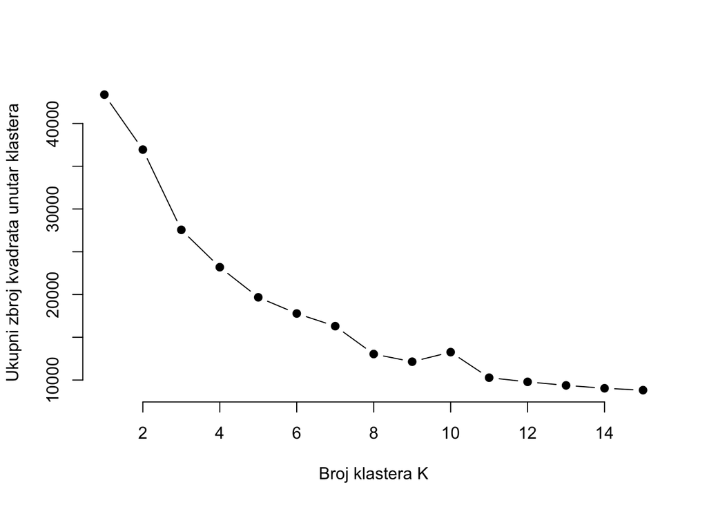

```r
# Određivanje optimalnog broja klastera pomoću metode lakta
set.seed(123)
wss <- function(k){
  kmeans(kupci_bez_ID.s,k,nstart=10)$tot.withinss
}
k.values <- 1:15

# extract wss for 2-15 clusters
wss_values <- map_dbl(k.values, wss)

plot(k.values, wss_values,
       type="b", pch = 19, frame = FALSE,
       xlab="Broj klastera K",
       ylab="Ukupni zbroj kvadrata unutar klastera")
```

Vidljivo je da krivulja brzo pada do točke između 2 i 4 na x-osi, nakon čega pad postaje puno blaži. Optimalan broj klastera je obično tamo gdje krivulja počinje splašnjavati. Čini se da bi “lakat” mogao biti oko 3 ili 4 klastera.

```r
k3 <- kmeans(kupci_bez_ID.s, centers = 3, nstart = 25)
str(k3)
```

```
## List of 9
##  $ cluster     : int [1:4338] 3 1 1 2 1 1 1 2 1 1 ...
##  $ centers     : num [1:3, 1:10] -0.331 1.742 -1.029 -0.271 1.425 ...
##   ..- attr(*, "dimnames")=List of 2
##   .. ..$ : chr [1:3] "1" "2" "3"
##   .. ..$ : chr [1:10] "avgBrArt" "minBrArt" "maxBrArt" "minPrice" ...
##  $ totss       : num 43370
##  $ withinss    : num [1:3] 11516 13555 2490
##  $ tot.withinss: num 27561
##  $ betweenss   : num 15809
##  $ size        : int [1:3] 3643 693 2
##  $ iter        : int 3
##  $ ifault      : int 0
##  - attr(*, "class")= chr "kmeans"
```